# Assignment 1 Instructions

Due Date: 2/25/26 (FLEX to 3/4/26)

**Note💪 FLEX rules**

- You have to get started to FLEX! Submit what you have by the original due date, then message me if you need to FLEX, lmk what’s up
- Be aware of accumulating deadlines when you think about FLEXING

# AI Use Policy for this Assignment

AI Policy Details

[output not shown]

**Important**

If you do choose to use AI, please disclose it and include a link to the chat.

# Assignment Objective

This assignment is designed to simulate a real-world data visualization task where you will analyze, deconstruct, and accurately recreate a provided visualization using a tool of your choice (you can use more if you like). One of the most important skills in the workforce is choosing the right tool for the job, getting a sense for varying levels of **features, interactivity, and customizability** available with different visualization software tools, and figuring out which tools you would rather avoid (this will help you when it comes time to pick tools for your group project!).

# How to Submit

Submit your work in the following formats:

- **Final Visualizations + captions** (.pdf, .docx, or .ppt). Put the captions below the image (or use the built-in captioning functionality of the tool, if applicable)
- **Process Documentation** (Notebook File, PDF, Word, or .mp4) and **Code Files** (include any files necessary to run the code)
- **Reflection Response** (Complete via Blackboard, which links to Google Assignments. Don’t forget to press submit!)

**Important**

**Please do not put it in a zip archive!**

# Assignment Instructions: Step-by-Step

## Step 0: Choose one or two Visualizations to Recreate

1. Browse the set of [provided visualizations and datasets](https://padlet.com/rmwillia2/assignment-1-visualizations-data-4zfmrymkyzvf9vzo) .Each vis is accompanied by the dataset used to create it. Select one or two visualizations to attempt to recreate.
2. Familiarize yourself with the dataset and its structure. Do some exploring on the [Data to Viz](https://www.data-to-viz.com/) site to learn common vis names, caveats, and some tips to create them. As a hint, I have put the chart name in brackets for each image (though sometimes names will differ!)
3. Decide whether you will use AI or not – if you use it, be sure to include the link in your submission

## Step 1: Recreate the vis with your chosen tool

1. First, choose an appropriate tool for your chosen vis from the list of approved tools below. You can change your mind at any time.

[Holoviz Panel](https://panel.holoviz.org/)

[Manim](https://3b1b.github.io/manim/getting_started/example_scenes.html)

[Unreal Engine](https://www.unrealengine.com/en-US)

[CosmoGraph](https://github.com/cosmograph-org/cosmos)

[Bokeh](https://docs.bokeh.org/en/latest/)

[Vega-Lite](https://vega.github.io/vega-lite/)

[Gephi](https://gephi.org/)

[Seaborn](https://seaborn.pydata.org/)

[Folium](https://python-visualization.github.io/folium/)

[Plotly](https://plotly.com/python/)

[MATLAB](https://www.mathworks.com/products/matlab.html)

[Shiny](https://shiny.rstudio.com/)

[D3.js](https://d3js.org/)

[Matplotlib](https://matplotlib.org/stable/gallery/index.html)

[Blender](https://www.blender.org/)

[QGIS](https://www.qgis.org/en/site/)

[Google Charts](https://developers.google.com/chart)

[VisIt](https://visit-dav.github.io/visit-website/)

[OpenGL](https://www.opengl.org/)

[VTK](https://vtk.org/)

[Unity](https://unity.com/)

[Orange](https://orangedatamining.com/)

2. Next, load and prepare the dataset.

   **Note**

   The dataset may require preprocessing (e.g., filtering, cleaning, or restructuring) to match the visual representation in the original image. You should document any changes you make to the dataset to recreate the visualization. You can add auxiliary data as needed, but don’t forget to cite and document it!

   **TipFAQs**
   - Do we have to write code to stream the data from the Google Docs link?
3. Write some code to recreate the visualization(s) as accurately as you can

   **TipFAQs**
   - Do I need to try and replicate even the little icons and shapes?
   - Do we have to match the colors too?
   - What if I can’t get an exact 1:1 replica?
4. Write a step-by-step breakdown of how you created each visualization (for eample, any data cleaning or transformation required, how to change the formatting to match the original, how to add text and/or annotations, etc.).

   You can do this by choosing one or more of these options:
   - (preferred option) Interspersing markdown cells with your code cells in notebook environments, such as [Colab](https://colab.google/), [Jupyter](https://jupyter.org/), [Observable](https://observablehq.com/), [R](https://rmarkdown.rstudio.com/lesson-10.html), [Matlab](https://www.mathworks.com/products/matlab-online.html). Also export to .pdf if possible.
   - Use [Quarto](https://quarto.org/) to intersperse text and code (node you’ll still need to upload the runnable code)
   - Including block comments in your code, and line comments as well (ok option, but gets hard to read fast)
   - Screenshotting code snippets and putting them into a word doc interspersed with text (not recommended, but you do you)
   - Narrating a screen-capture video of you writing the code while explaining what you’re doing. Be sure to include closed captions/subtitles (great choice if you don’t like fiddling with documents)

   Your documentation should be clear enough that another student could **follow your steps and recreate your visualization** without prior knowledge of the data or tool.

   **TipFAQs**
   - If I choose the video option, can I use AI to generate the narration?
   - How beautiful does my code need to be?

## Step 2: Add a descriptive caption to your vis

Add a caption summarizing the visualization’s purpose and encodings. Check out [this resource](https://chec.engineering.cornell.edu/visuals/captions-for-figures-in-documents/) for how to write great captions.

Some vis tools have built-in functionality for creating captions, others don’t. If you choose a tool that doesn’t, find a workaround, and then you can mention how annoying it was to have to do that in your reflection 😀.

**Note**

Captions are more than just titles! They should be able to stand alone if taken out of context, succinctly describing the main points the viewer should take away from looking at this image: What is being shown? What are the salient features? What **task or analysis question** can be completed or addressed by this vis?

## Step 3: Reflection

**Important**

Please type in the Google Assignent doc provided on Blackboard, don’t copy paste from another doc, or it will get flagged as plagiarism by the system! Also pls no AI

As you’re working, take some time to reflect and write some short notes about:

- Which tools did you consider, and which did you end up choosing to use, and why?
- What challenges did you encounter in replicating the visualization?
- Did you have to modify the dataset in any way to get the desired output?
- Which features of your tool helped or hindered the recreation process (strengths/limitations)?
- Are there elements of the original visualization that were difficult or impossible to replicate? If so, why?
- What is one piece of advice you would give someone wanting to use this tool?
- If you had to do this again, would you choose the same tool? Why or why not?

Write your reflection via Blackboard under **Assignment 1 Part 2**, then don’t forget to press ✨Submit ✨

**TipFAQs**

- Are bullets fine for my reflection, or do you want a full essay?

# Hints

# Frequently Asked Questions

**NoteDo we have to write code to stream the data from the Google Docs link?**

No! Feel free to do whatever causes less friction. If using a notebook, you can drag the data into your runtime, but note it will disappear at the end of each session, unless you connect it to a static cloud source. If you’re writing code locally, feel free to download the data and then read in with any read function (Pandas can be great for this in Python)

**NoteHow beautiful does my code need to be?**

Not pristine, just readable. Please dont pass it thruugh AI though, as that may cause the system to flag for verbatim text

**NoteWhat if I can’t get an exact 1:1 replica?**

Try and get as close as you can, and then in your reflection you can talk about how yours differs from the original, what elements of the original you were unable to figure out how to do, why, and propose a solution if you had more time.

**NoteDo I need to try and replicate even the little icons and shapes?**

If the vis has fancy little icons or weird shapes, you can omit those. For example, the little people icons in this bar chart’s legend (however, you should still include the legend!)

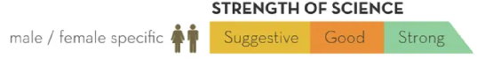

**NoteAre bullets fine for my reflection, or do you want a full essay?**

Bullets are fine as long as I can understand your experience, and it’s clear which question you’re answering. If two questions tie together you may want to change the ordering, group questions, etc. for better flow Also feel free to write it as standard prose or train of thought, whatever you prefer!

**NoteCan I use AI to generate the narration?**

Sure, but you’d then need to write a script in your own words, and at that point why not just write it down? I guess you could do voice to text back to AI voice…sounds complicated, but up to you. Don’t forget the closed captions also!

**NoteWhat if I want/need to use a different format?**

Shoot me a message and we’ll figure it out!

# Grading

## Originality Checks

The following checks will be performed for each submission; If any of these validation conditions are not satisfied, your assignment will be returned to you with or without options for remediation:

- Ensure that your recreated visualization was generated from the dataset, not simply redrawn in Canva or other drawing program. - Please refer to the syllabus for the course policy on Academic Misconduct
- AI Policy must be followed, including a link to the chat
- Responses to reflection questions must be **specific** to your experience – generic AI-generated answers will be flagged.

## Timeliness

**Requests for extensions must be made to the Professor before the assignment due date and time (by 9 pm).**

#### Late Deduction Calculator

[interactive chart not shown]

## Rubric

[link to the rubric](https://docs.google.com/document/d/1M48jyPlo-0PRHYyHykHNHTUVxXRB7--es63Aw4YMVHw/preview)